Home Loan Data Set - Loan Status as label

```r
library(data.table)
library(ggplot2)
home.dt <- fread("home_train.csv")
#class(home.dt)
summary(home.dt)
```

```
##    Loan_ID             Gender            Married           Dependents
##  Length:614         Length:614         Length:614         Length:614
##  Class :character   Class :character   Class :character   Class :character
##  Mode  :character   Mode  :character   Mode  :character   Mode  :character
##
##
##
##
##   Education         Self_Employed      ApplicantIncome CoapplicantIncome
##  Length:614         Length:614         Min.   :  150   Min.   :    0
##  Class :character   Class :character   1st Qu.: 2878   1st Qu.:    0
##  Mode  :character   Mode  :character   Median : 3812   Median : 1188
##                                        Mean   : 5403   Mean   : 1621
##                                        3rd Qu.: 5795   3rd Qu.: 2297
##                                        Max.   :81000   Max.   :41667
##
##    LoanAmount    Loan_Amount_Term Credit_History   Property_Area
##  Min.   :  9.0   Min.   : 12      Min.   :0.0000   Length:614
##  1st Qu.:100.0   1st Qu.:360      1st Qu.:1.0000   Class :character
##  Median :128.0   Median :360      Median :1.0000   Mode  :character
##  Mean   :146.4   Mean   :342      Mean   :0.8422
##  3rd Qu.:168.0   3rd Qu.:360      3rd Qu.:1.0000
##  Max.   :700.0   Max.   :480      Max.   :1.0000
##  NA's   :22      NA's   :14       NA's   :50
##  Loan_Status
##  Length:614
##  Class :character
##  Mode  :character
##
##
##
##
```

```r
sum(is.na(home.dt)) #86 missing values
```

```
## [1] 86
```

```r
apply(home.dt,2,function(x) any(is.na(x)))
```

```
##           Loan_ID            Gender           Married        Dependents
##             FALSE             FALSE             FALSE             FALSE
##         Education     Self_Employed   ApplicantIncome CoapplicantIncome
##             FALSE             FALSE             FALSE             FALSE
##        LoanAmount  Loan_Amount_Term    Credit_History     Property_Area
##              TRUE              TRUE              TRUE             FALSE
##       Loan_Status
##             FALSE
```

```r
#Id which variables have the most missing values and where
home.dt[is.na(LoanAmount),.N]
```

```
## [1] 22
```

Columns - LoanAmount, Credit_History,Loan_Amount_Term having NA values but null values ignored

```r
#Change read
home2.dt <- fread('home_train.csv', na.strings = c("NA", "missing", "N/A", -99, "", "m", "M", "na", "."))
sum(is.na(home2.dt)) #86 missing values
```

```
## [1] 149
```

```r
apply(home2.dt,2,function(x) any(is.na(x))) #Missing values show up
```

```
##           Loan_ID            Gender           Married        Dependents
##             FALSE              TRUE              TRUE              TRUE
##         Education     Self_Employed   ApplicantIncome CoapplicantIncome
##             FALSE              TRUE             FALSE             FALSE
##        LoanAmount  Loan_Amount_Term    Credit_History     Property_Area
##              TRUE              TRUE              TRUE             FALSE
##       Loan_Status
##             FALSE
```

```r
#is.na(home2.dt$Married)
summary(home2.dt$LoanAmount)
```

```
##    Min. 1st Qu.  Median    Mean 3rd Qu.    Max.    NA's
##     9.0   100.0   128.0   146.4   168.0   700.0      22
```

1. Any value in dropping the customer_ID? Because eventually want to identify these customers Clean vital few stats like: Gender:

```r
summary(home2.dt$Gender)
```

```
##    Length     Class      Mode
##       614 character character
```

```r
# Value = Missing may be people who don't identify as male/female
# Create a new column complete_gender. Temporary recode NA as missing in complete_gender column.
#Convert to factor
home2.dt[Gender == 'Male',  complete_gender:= 'male']
home2.dt[Gender == 'Female', complete_gender:= 'female']
home2.dt[is.na(Gender), complete_gender:='missing']
home2.dt$Gender <- factor(home2.dt$complete_gender, levels = c('missing', 'male', 'female')) #encode as a factor
summary(home2.dt$Gender)
```

```
## missing    male  female
##      13     489     112
```

Clean Married as factor with 1 or 0, nominal variable:

```r
summary(home2.dt$Married)
```

```
##    Length     Class      Mode
##       614 character character
```

```r
home2.dt[Married == 'Yes',  complete_married:= '1']
home2.dt[Married == 'No', complete_married:= '0']
home2.dt[is.na(Married), complete_married:='2']
home2.dt$Married <- factor(home2.dt$complete_married, levels = c('0', '1', '2'))
summary(home2.dt$Married)
```

```
##   0   1   2
## 213 398   3
```

Clean Education

```r
summary(home2.dt$Education)
```

```
##    Length     Class      Mode
##       614 character character
```

```r
home2.dt[Education == 'Graduate',  complete_edu:= '1']
home2.dt[Education== 'Not Graduate', complete_edu:= '0']
home2.dt[is.na(Education), complete_edu:='2']
home2.dt$Education <- factor(home2.dt$complete_edu, levels = c('0', '1', '2'))
summary(home2.dt$Education)
```

```
##   0   1   2
## 134 480   0
```

Clean Self-Employed

```r
summary(home2.dt$Self_Employed)
```

```
##    Length     Class      Mode
##       614 character character
```

```r
home2.dt[Self_Employed == 'No',  biz_owner:= '0']
home2.dt[Self_Employed == 'Yes', biz_owner:= '1']
home2.dt[is.na(Self_Employed), biz_owner:='2']
home2.dt$Self_Employed <- factor(home2.dt$biz_owner, levels = c('0', '1', '2'))
summary(home2.dt$Self_Employed)
```

```
##   0   1   2
## 500  82  32
```

Clean Property_Area - could explore making these ordinal var? Unlikely to be true homeless people

```r
summary(home2.dt$Property_Area)
```

```
##    Length     Class      Mode
##       614 character character
```

```r
home2.dt[Property_Area == 'Urban',  prop:= 'U']
home2.dt[Property_Area == 'Semiurban', prop:= 'SU']
home2.dt[Property_Area == 'Rural', prop:= 'R']
home2.dt$Property_Area <- factor(home2.dt$prop, levels = c('U', 'SU', 'R','M'))
summary(home2.dt$Property_Area)
```

```
##   U  SU   R   M
## 202 233 179   0
```

Clean Loan_Status

```r
home2.dt$Loan_Status <- as.factor(home2.dt$Loan_Status)
```

Check status 2. Dummy variables for the categorical variables?

```r
summary(home2.dt)
```

```
##    Loan_ID              Gender    Married  Dependents        Education
##  Length:614         missing: 13   0:213   Length:614         0:134
##  Class :character   male   :489   1:398   Class :character   1:480
##  Mode  :character   female :112   2:  3   Mode  :character   2:  0
##
##
##
##
##  Self_Employed ApplicantIncome CoapplicantIncome   LoanAmount
##  0:500         Min.   :  150   Min.   :    0     Min.   :  9.0
##  1: 82         1st Qu.: 2878   1st Qu.:    0     1st Qu.:100.0
##  2: 32         Median : 3812   Median : 1188     Median :128.0
##                Mean   : 5403   Mean   : 1621     Mean   :146.4
##                3rd Qu.: 5795   3rd Qu.: 2297     3rd Qu.:168.0
##                Max.   :81000   Max.   :41667     Max.   :700.0
##                                                  NA's   :22
##  Loan_Amount_Term Credit_History   Property_Area Loan_Status complete_gender
##  Min.   : 12      Min.   :0.0000   U :202        N:192       Length:614
##  1st Qu.:360      1st Qu.:1.0000   SU:233        Y:422       Class :character
##  Median :360      Median :1.0000   R :179                    Mode  :character
##  Mean   :342      Mean   :0.8422   M :  0
##  3rd Qu.:360      3rd Qu.:1.0000
##  Max.   :480      Max.   :1.0000
##  NA's   :14       NA's   :50
##  complete_married   complete_edu        biz_owner             prop
##  Length:614         Length:614         Length:614         Length:614
##  Class :character   Class :character   Class :character   Class :character
##  Mode  :character   Mode  :character   Mode  :character   Mode  :character
##
##
##
##
```

Clean continuous variables: LoanAmount, Loan_Amount_Term, Credit_History to then do distribution plots Total of 22 + 14 + 50 missing cont variables => substantial? should find a way to deal with them?

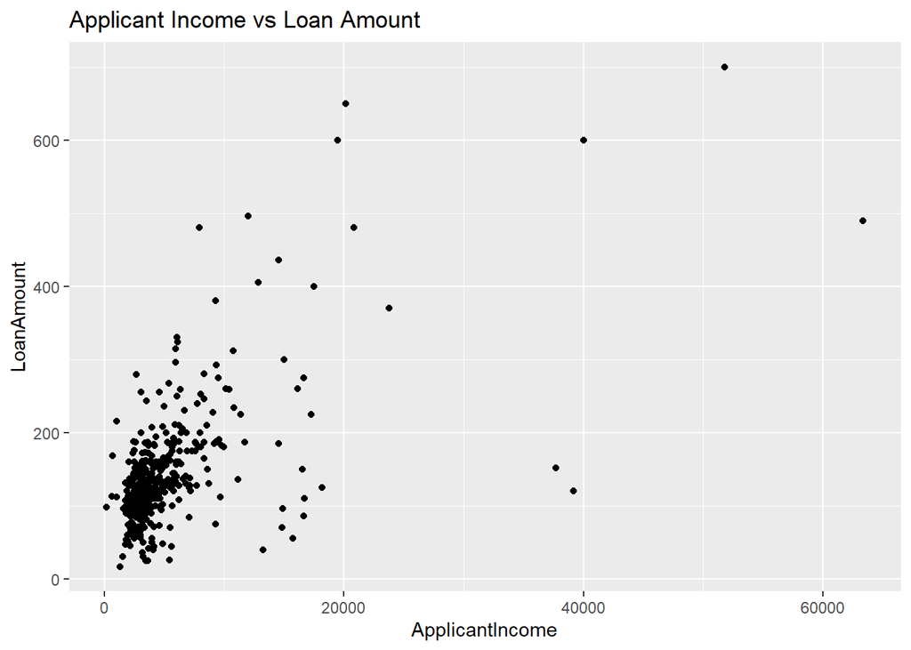

```r
ggplot(data = home2.dt[Loan_Status == "Y"], aes(x =ApplicantIncome , y = LoanAmount)) +
  geom_point() +
  #facet_grid(. ~ month) +
  labs(title = "Applicant Income vs Loan Amount")
```

^ Looks interesting, hence explore any other linear r/s never considered using a correlation matrix?

Other data sets used log transform to drop outliers

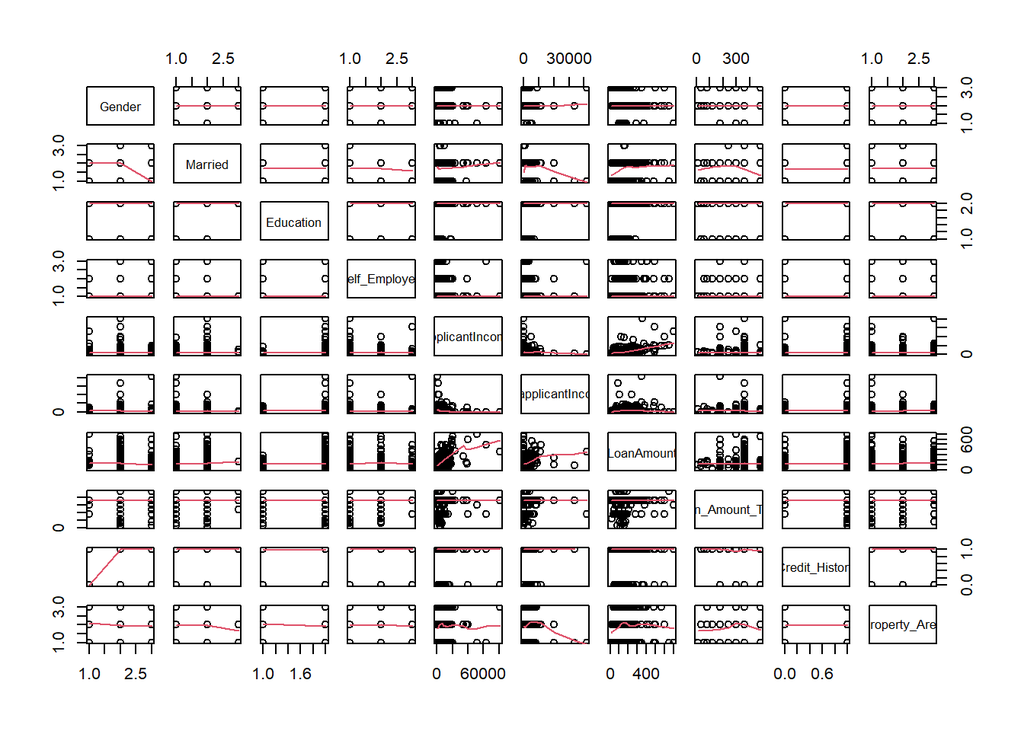

```r
pairs(~ Gender+Married+Education+Self_Employed+ApplicantIncome+CoapplicantIncome+LoanAmount+Loan_Amount_Term+Credit_History+Property_Area, panel=panel.smooth, data = home2.dt)
```

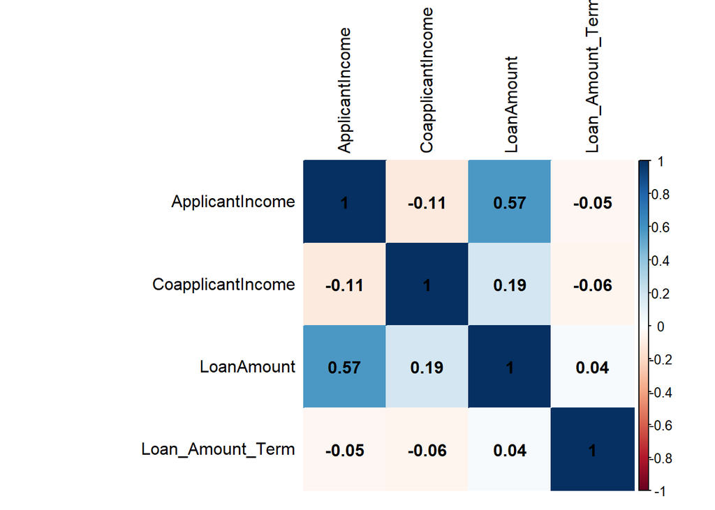

```r
library(corrplot)
M<- cor(home2.dt[,c('ApplicantIncome','CoapplicantIncome','LoanAmount','Loan_Amount_Term')],use='complete.obs')
corrplot(M, method="color",addCoef.col = "black",tl.col = "black")
```

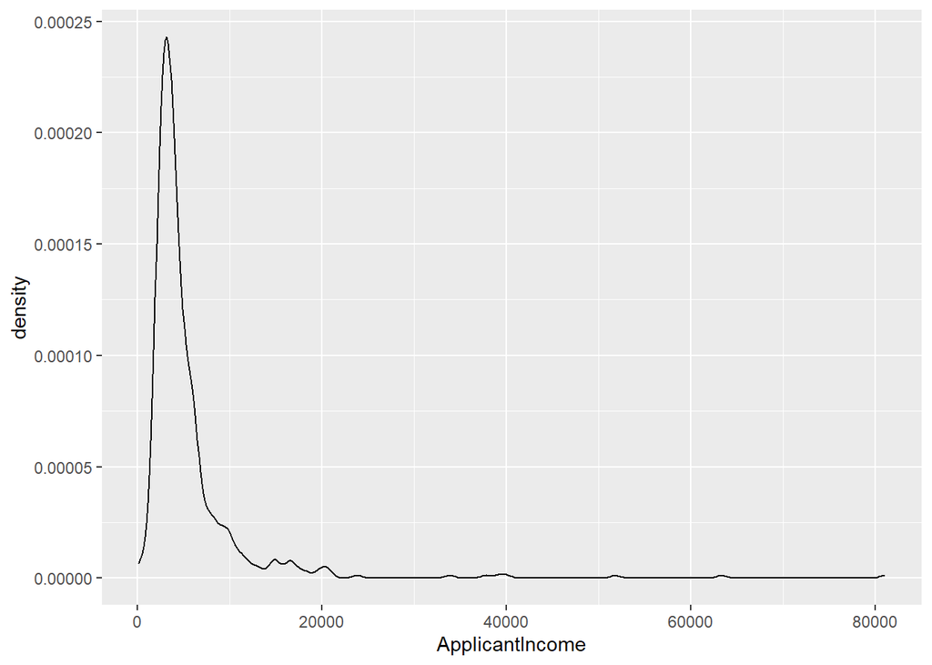

```r
# Density Plot to see distribution of continuous varable.
ggplot(home2.dt,aes(ApplicantIncome)) + geom_density()
```

```r
which.max(density(home2.dt$ApplicantIncome)$y)
```

```
## [1] 29
```

```r
density(home2.dt$ApplicantIncome)$x[29]
```

```
## [1] 3130.609
```

```r
cor(home2.dt$CoapplicantIncome,home2.dt$ApplicantIncome)
```

```
## [1] -0.1166046
```

```r
summary(home2.dt)
```

```
##    Loan_ID              Gender    Married  Dependents        Education
##  Length:614         missing: 13   0:213   Length:614         0:134
##  Class :character   male   :489   1:398   Class :character   1:480
##  Mode  :character   female :112   2:  3   Mode  :character   2:  0
##
##
##
##
##  Self_Employed ApplicantIncome CoapplicantIncome   LoanAmount
##  0:500         Min.   :  150   Min.   :    0     Min.   :  9.0
##  1: 82         1st Qu.: 2878   1st Qu.:    0     1st Qu.:100.0
##  2: 32         Median : 3812   Median : 1188     Median :128.0
##                Mean   : 5403   Mean   : 1621     Mean   :146.4
##                3rd Qu.: 5795   3rd Qu.: 2297     3rd Qu.:168.0
##                Max.   :81000   Max.   :41667     Max.   :700.0
##                                                  NA's   :22
##  Loan_Amount_Term Credit_History   Property_Area Loan_Status complete_gender
##  Min.   : 12      Min.   :0.0000   U :202        N:192       Length:614
##  1st Qu.:360      1st Qu.:1.0000   SU:233        Y:422       Class :character
##  Median :360      Median :1.0000   R :179                    Mode  :character
##  Mean   :342      Mean   :0.8422   M :  0
##  3rd Qu.:360      3rd Qu.:1.0000
##  Max.   :480      Max.   :1.0000
##  NA's   :14       NA's   :50
##  complete_married   complete_edu        biz_owner             prop
##  Length:614         Length:614         Length:614         Length:614
##  Class :character   Class :character   Class :character   Class :character
##  Mode  :character   Mode  :character   Mode  :character   Mode  :character
##
##
##
##
```